```python
### This is for ignoring UndefinedMetricWarning by Sklearn
from warnings import simplefilter
from sklearn.exceptions import UndefinedMetricWarning
simplefilter("ignore", category=UndefinedMetricWarning)

import matplotlib.pyplot as plt
import numpy as np
import pandas as pd
from sklearn.svm import SVC
import plotly.express as px
```

# $k$-Means Clustering

We will be using the IRIS dataset ([Source](https://archive.ics.uci.edu/ml/datasets/iris)) for illustrating $k$-means clustering.

The data set contains 3 classes of 50 instances each, where each class refers to a type of iris plant.

**Output classes**

| Labels | Classes |
| --- | --- |
| 0 | Iris **Setosa** |
| 1 | Iris **Versicolour** |
| 2 | Iris **Virginica** |

The data has 4 input features.

**Input features**

| Features (in cm) |  |
| --- | --- |
| 1. sepal length |  |
| 2. sepal width |  |
| 3. petal length |  |
| 4. petal width |  |

Since we are using unsupervised learning, let's ignore the class labels.

## Loading the IRIS dataset

Let's load the data and observe how the data is distributed.

```python
### Loading the dataset and creating input and output parameters
from sklearn.datasets import load_iris
iris = load_iris()
X = iris.data[:, :4]
y = iris.target

import pandas as pd
import numpy as np
iris_df = pd.DataFrame(
    np.c_[iris['data'],iris['target']],
    columns=np.append(iris['feature_names'], 'iris_species')
)

fig = px.scatter_3d(iris_df, x='sepal length (cm)', y='sepal width (cm)', z='petal width (cm)',
              # color='iris_species'
              )
fig.show()
```

[interactive chart not shown]

As, we do not have access to the labels of the data in unsupervised learning. Thus, the Iris dataset will look like the previous figure:

We can observe that:

> 1. There are two clusters.
> 2. One of the clusters has more data than the other.

For simplifying the classification of the dataset using $k$-means,

> 1. Let's consider only two features: `Petal length (cm)` and `petal width (cm)` to reduce the dataset into two dimensions for a better understanding.

## Visual understanding of the data in 2D

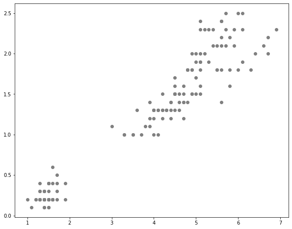

```python
##### considering only two features: Petal length (cm) and petal width (cm).
iris_df_2d = iris_df[['petal length (cm)','petal width (cm)']]

##### Let's see the data
plt.figure(figsize=(10,8))
scatter = plt.scatter(iris_df_2d['petal length (cm)'], iris_df_2d['petal width (cm)'], c='gray')
```

We can observe that the data can be split into two clusters.

The `Setosa` species should have 50 data points. It appears to have less than 50 points because some of the points have the same petal width and petal length. They are overlapped.

We will create a $k$-means clustering model for classification.

## $k$-Means Clustering - Two Clusters

### Initialization

Initialization consists of two steps:

> 1. Selecting the number of clusters. Here, we select $n=2$.
> 2. Locate the centroids. Let's initialize the centroids at two random points of the dataset.

We can initialize to a set of custom points as well.

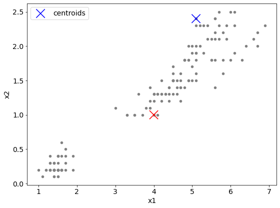

```python
# Initialize k
k = 2

colors = ["#FFC000", "#9DC3E6", "#C27CE8"]

# Pick k centroids randomly
X = np.array(iris_df_2d)
np.random.seed(0)
idx = np.random.choice(len(X), k, replace=False)
centroids = X[idx, :]

# Visualize picked centroids
plt.figure(figsize=(8, 6))
plt.rcParams.update({"font.size": 14})
plt.scatter(X[:, 0], X[:, 1], s=20, c="gray")
plt.scatter(centroids[:, 0], centroids[:, 1], s=300, marker="x", c=['b','r'], label='centroids')
plt.legend()
plt.xlabel("x1")
plt.ylabel("x2")
plt.tight_layout()
plt.show()
```

We have seen the locations of the initialized centroids.

Now, we need to attribute each point in the dataset to one of the centroids.

Let's attribute each point in the dataset to the centroid which is closest to it.

```python
from scipy.spatial.distance import cdist
# Find the distance between centroids and all the data points
distances = cdist(X, centroids ,'euclidean')

# Assign each data point to the closest centroid
y_pred = np.array([np.argmin(i) for i in distances])

print("Predicted clusters: \n", y_pred)
```

```
Predicted clusters:
 [1 1 1 1 1 1 1 1 1 1 1 1 1 1 1 1 1 1 1 1 1 1 1 1 1 1 1 1 1 1 1 1 1 1 1 1 1
 1 1 1 1 1 1 1 1 1 1 1 1 1 1 1 0 1 1 1 0 1 1 1 1 1 1 1 1 1 1 1 1 1 0 1 0 1
 1 1 1 0 1 1 1 1 1 0 1 1 1 1 1 1 1 1 1 1 1 1 1 1 1 1 0 0 0 0 0 0 1 0 0 0 0
 0 0 0 0 0 0 0 0 0 0 0 0 0 0 0 0 0 0 0 0 0 0 0 0 0 0 0 0 0 0 0 0 0 0 0 0 0
 0 0]
```

Now, we have labeled each point in the dataset with one of the centroids depending on the ditance of the centroids from the data point in consideration.

Let's see how the data looks like.

```
There are 55 points in the blue cluster and 95 points in the red cluster.
```

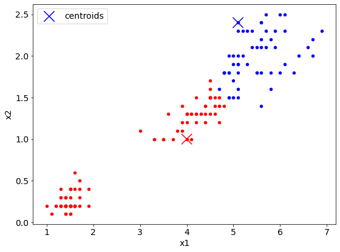

```python
cluster_1 = X[y_pred == 0, :]
cluster_2 = X[y_pred == 1, :]

print(f'There are {len(cluster_1)} points in the blue cluster and {len(cluster_2)} points in the red cluster.\n\n')

# Visualize the clustering result
plt.figure(figsize=(8, 6))
plt.rcParams.update({"font.size": 14})
plt.scatter(cluster_1[:, 0], cluster_1[:, 1], s=20, c='b')
plt.scatter(cluster_2[:, 0], cluster_2[:, 1], s=20, c='r')
plt.scatter(centroids[:, 0], centroids[:, 1], s=300, marker="x", c=['b','r'],label='centroids')
plt.legend()
plt.xlabel("x1")
plt.ylabel("x2")
plt.tight_layout()
plt.show()
```

We have two centroids, represented with `X` markers.

We can also notice that the points which are `blue` are close to the centroid colored `blue`, and vice versa.

### First iteration

Now, we have two clusters created using the centroids.

The next step is to compute the centroids of the created clusters and move the previous centroids to the newly computed locations.

```
New centroids:
 [[5.5        1.98727273]
 [2.74947368 0.74315789]]
```

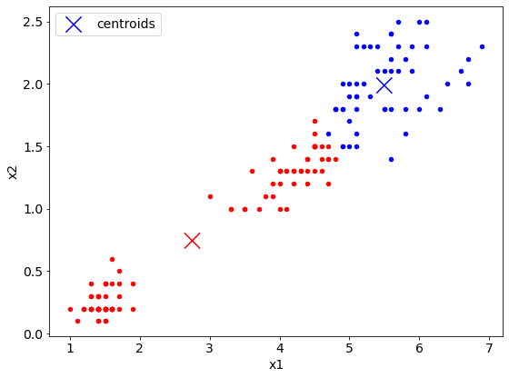

```python
# Find new centroids as barycenter of each cluster
new_centroids = np.zeros(shape=(k, X.shape[1]))

for i in range(k):
    # Update centroids by taking mean of the cluster it belongs to
    new_centroids[i] = (X[y_pred == i, :].mean(axis=0))

print("New centroids: \n", new_centroids)

# Visualize the new centroids
plt.figure(figsize=(8, 6))
plt.rcParams.update({"font.size": 14})
plt.scatter(cluster_1[:, 0], cluster_1[:, 1], s=20, c='b')
plt.scatter(cluster_2[:, 0], cluster_2[:, 1], s=20, c='r')
plt.scatter(new_centroids[:, 0], new_centroids[:, 1], s=300, marker="x", c=['b','r'], label='centroids')
plt.legend()
plt.xlabel("x1")
plt.ylabel("x2")
plt.tight_layout()
plt.savefig("05.svg")
plt.show()
```

Now, we see that the centroids moved to the new locations.

The data is labeled the same as that in the previous plot.

### A full run of iterations

The next step is to identify the nearest (newly computed) centroid from each point and re-label the points.

And, continue the same until convergence.

```
The coordinates of the current centroid is
[[5.17160494 1.79876543]
 [2.09855072 0.49565217]]
There are 81 points in the blue cluster and 69 points in the red cluster.
The average distance of the points in the dataset from the nearest centroid is 0.07767542686672316
```

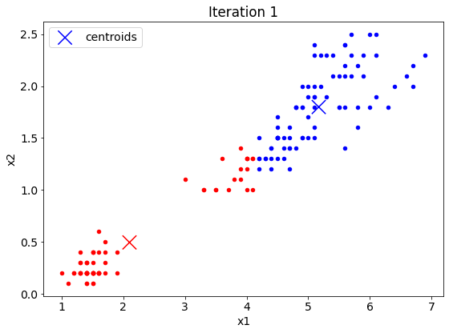

```
The coordinates of the current centroid is
[[4.98947368 1.71052632]
 [1.63090909 0.31636364]]
There are 95 points in the blue cluster and 55 points in the red cluster.
The average distance of the points in the dataset from the nearest centroid is 0.0633409380140165
```

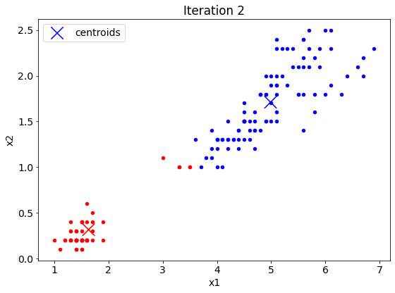

```
The coordinates of the current centroid is
[[4.95876289 1.69587629]
 [1.56037736 0.29056604]]
There are 97 points in the blue cluster and 53 points in the red cluster.
The average distance of the points in the dataset from the nearest centroid is 0.06232013319539103
```

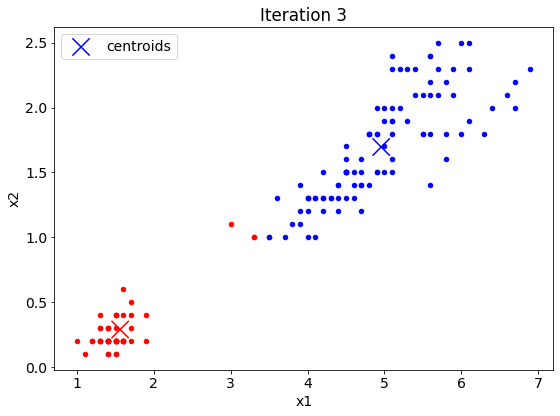

```
The coordinates of the current centroid is
[[4.92525253 1.68181818]
 [1.49215686 0.2627451 ]]
There are 99 points in the blue cluster and 51 points in the red cluster.
The average distance of the points in the dataset from the nearest centroid is 0.06196422618307506
```

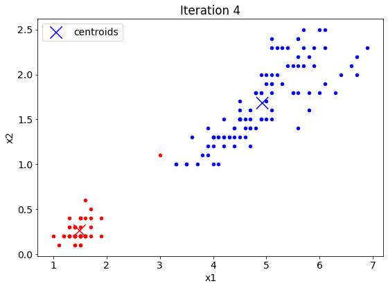

```
The coordinates of the current centroid is
[[4.92525253 1.68181818]
 [1.49215686 0.2627451 ]]
There are 99 points in the blue cluster and 51 points in the red cluster.
The average distance of the points in the dataset from the nearest centroid is 0.06196422618307506
```

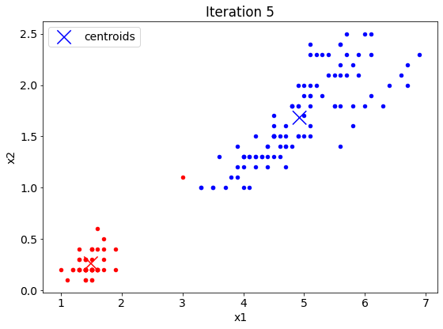

```python
# Init iterations
iterations = 5

for i in range(iterations):
    # Find the distance between centroids and all the data points
    distances = cdist(X, new_centroids ,'euclidean')

    # Assign each data point to the closest centroid
    y_pred = np.array([np.argmin(i) for i in distances])


    # Find new centroids as barycenter of each cluster
    new_centroids = np.zeros(shape=(k, X.shape[1]))
    for j in range(k):
        # Update centroids by taking mean of the cluster it belongs to
        new_centroids[j] = (X[y_pred == j, :].mean(axis=0))

    # Visualize

    print(f'\nThe coordinates of the current centroid is \n{new_centroids}')
    cluster_1 = X[y_pred == 0, :]
    cluster_2 = X[y_pred == 1, :]
    print(f'There are {len(cluster_1)} points in the blue cluster and {len(cluster_2)} points in the red cluster. ')

    # ### Helper function for evaluation - average distance of the dataset from the centroids
    nearest_centroid = np.array([new_centroids[i,:] for i in y_pred])
    avg_dist_from_centroid = (np.linalg.norm(X-nearest_centroid)) /len(X)
    print(f'The average distance of the points in the dataset from the nearest centroid is {avg_dist_from_centroid}')

    plt.figure(figsize=(8, 6))
    plt.rcParams.update({"font.size": 14})
    plt.scatter(cluster_1[:, 0], cluster_1[:, 1], s=20, c='b')
    plt.scatter(cluster_2[:, 0], cluster_2[:, 1], s=20, c='r')
    plt.scatter(new_centroids[:, 0], new_centroids[:, 1], s=300, marker="x", c=['b','r'],label='centroids')
    plt.legend()
    plt.xlabel("x1")
    plt.ylabel("x2")
    plt.title(f"Iteration {i+1}")
    plt.tight_layout()
    plt.show()
```

We can notice from the coordinates of the centroids in the last two iterations to be approximately similar. We stop our iteration here.

We have seen how classifying the Iris dataset into two clusters works.

Let's classify the Iris dataset into three clusters.

## $k$-Means Clustering - 3 Clusters

The steps remain the same:

> Initialization:
> > 1. Selecting the number of clusters. Here, we select $n=3$.
> > 2. Locate the centroids. Let's initialize the centroids at `three` random points of the dataset.

> > Iterations:
> > 1. Compute the distance of each centroid from the points in the dataset.
> > 2. Label the data point with the closest centroid. That will give us $n=3$ clusters.
> > 3. Compute the centroid of each cluster and update the location of centroids.
> > 4. Repeat the iterations until convergence.

```
The coordinates of the current centroid is
[[1.35       0.26153846]
 [1.76296296 0.31851852]
 [4.95876289 1.69587629]]
There are 26 points in the blue cluster and 27 points in the red cluster and 97 points in the green cluster .
The average distance of the points in the dataset from the nearest centroid is 0.06149386391325662
```

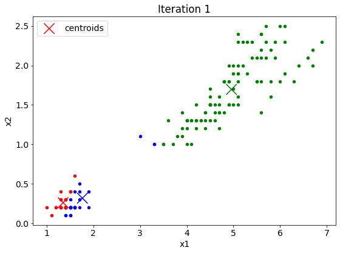

```
The coordinates of the current centroid is
[[1.38648649 0.22432432]
 [1.9625     0.44375   ]
 [4.95876289 1.69587629]]
There are 37 points in the blue cluster and 16 points in the red cluster and 97 points in the green cluster .
The average distance of the points in the dataset from the nearest centroid is 0.06078802090076155
```

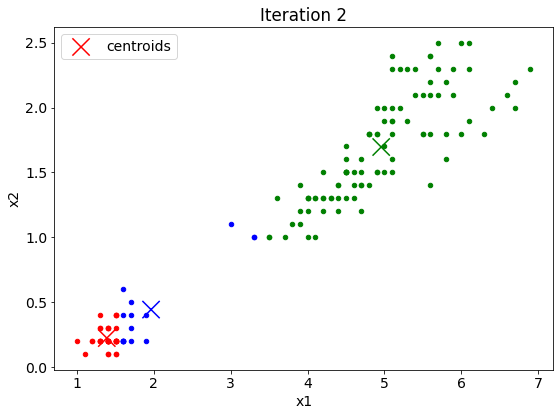

```
The coordinates of the current centroid is
[[1.42272727 0.225     ]
 [2.23333333 0.61111111]
 [4.95876289 1.69587629]]
There are 44 points in the blue cluster and 9 points in the red cluster and 97 points in the green cluster .
The average distance of the points in the dataset from the nearest centroid is 0.06013394814098763
```

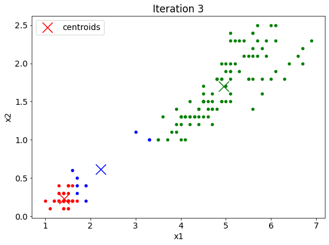

```
The coordinates of the current centroid is
[[1.45306122 0.24285714]
 [3.08333333 0.91666667]
 [4.98947368 1.71052632]]
There are 49 points in the blue cluster and 6 points in the red cluster and 95 points in the green cluster .
The average distance of the points in the dataset from the nearest centroid is 0.05720825692208123
```

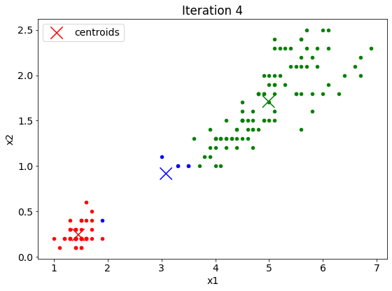

```
The coordinates of the current centroid is
[[1.462      0.246     ]
 [3.73529412 1.13529412]
 [5.14578313 1.78674699]]
There are 50 points in the blue cluster and 17 points in the red cluster and 83 points in the green cluster .
The average distance of the points in the dataset from the nearest centroid is 0.04867173162773737
```

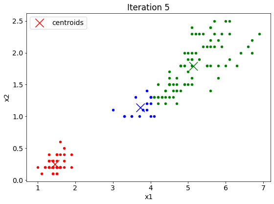

```
The coordinates of the current centroid is
[[1.462      0.246     ]
 [3.97333333 1.21333333]
 [5.30571429 1.87428571]]
There are 50 points in the blue cluster and 30 points in the red cluster and 70 points in the green cluster .
The average distance of the points in the dataset from the nearest centroid is 0.04263892947622286
```

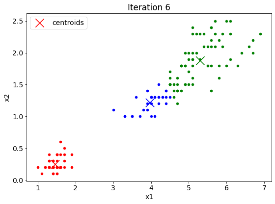

```
The coordinates of the current centroid is
[[1.462      0.246     ]
 [4.15348837 1.28837209]
 [5.47368421 1.96842105]]
There are 50 points in the blue cluster and 43 points in the red cluster and 57 points in the green cluster .
The average distance of the points in the dataset from the nearest centroid is 0.03847472301609864
```

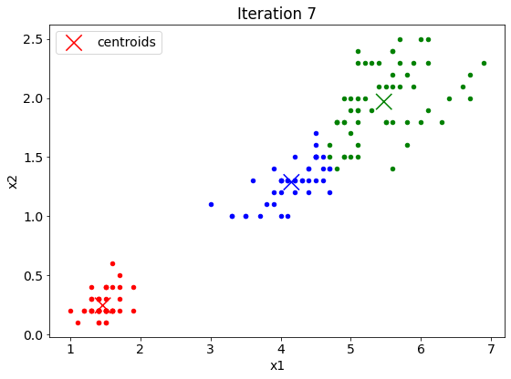

```
The coordinates of the current centroid is
[[1.462      0.246     ]
 [4.19130435 1.30217391]
 [5.51481481 1.99444444]]
There are 50 points in the blue cluster and 46 points in the red cluster and 54 points in the green cluster .
The average distance of the points in the dataset from the nearest centroid is 0.03767981235463277
```

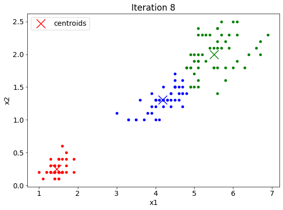

```
The coordinates of the current centroid is
[[1.462      0.246     ]
 [4.22083333 1.31041667]
 [5.53846154 2.01346154]]
There are 50 points in the blue cluster and 48 points in the red cluster and 52 points in the green cluster .
The average distance of the points in the dataset from the nearest centroid is 0.037529018212274196
```

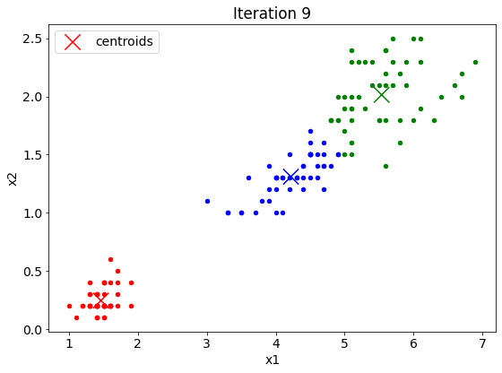

```
The coordinates of the current centroid is
[[1.462      0.246     ]
 [4.25490196 1.33921569]
 [5.58367347 2.02653061]]
There are 50 points in the blue cluster and 51 points in the red cluster and 49 points in the green cluster .
The average distance of the points in the dataset from the nearest centroid is 0.03737633958467234
```

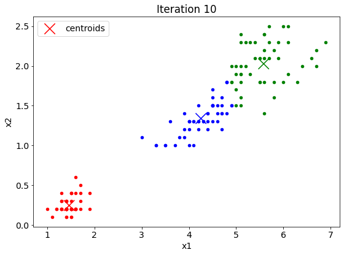

```python
# Initialize k
k = 3

# Pick k centroids randomly
np.random.seed(2)
idx = np.random.choice(len(X), k, replace=False)
new_centroids = X[idx, :]

# Init iterations
iterations = 10

for i in range(iterations):
    # Find the distance between centroids and all the data points
    distances = cdist(X, new_centroids ,'euclidean')

    # Assign each data point to the closest centroid
    y_pred = np.array([np.argmin(i) for i in distances])

    # Find new centroids as barycenter of each cluster
    new_centroids = np.zeros(shape=(k, X.shape[1]))
    for j in range(k):
        # Update centroids by taking mean of the cluster it belongs to
        new_centroids[j] = (X[y_pred == j, :].mean(axis=0))

    # Visualize
    print(f'\nThe coordinates of the current centroid is \n{new_centroids}')

    cluster_1 = X[y_pred == 0, :]
    cluster_2 = X[y_pred == 1, :]
    cluster_3 = X[y_pred == 2, :]
    print(f'There are {len(cluster_1)} points in the blue cluster and {len(cluster_2)} points in the red cluster and {len(cluster_3)} points in the green cluster . ')

    # ### Helper function for evaluation - average distance of the dataset from the centroids
    nearest_centroid = np.array([new_centroids[i,:] for i in y_pred])
    avg_dist_from_centroid = (np.linalg.norm(X-nearest_centroid)) /len(X)
    print(f'The average distance of the points in the dataset from the nearest centroid is {avg_dist_from_centroid}')

    plt.figure(figsize=(8, 6))
    plt.rcParams.update({"font.size": 14})
    plt.scatter(cluster_1[:, 0], cluster_1[:, 1], s=20, c='r')
    plt.scatter(cluster_2[:, 0], cluster_2[:, 1], s=20, c='b')
    plt.scatter(cluster_3[:, 0], cluster_3[:, 1], s=20, c='g')
    plt.scatter(new_centroids[:, 0], new_centroids[:, 1], s=300, marker="x", c=['r','b','g'],label='centroids')
    plt.legend()
    plt.xlabel("x1")
    plt.ylabel("x2")
    plt.title(f"Iteration {i+1}")
    plt.tight_layout()
    plt.show()
```

We can see that the Iris dataset can be classified into two or three clusters.

Number of centroids $k$ is an important hyperparatmer in $k$-means clustering.

The average distance of the points in the dataset from the nearest centroid is $0.061964$ in case of two clusters. It is $0.037376$ in case of three clusters, suggesting that the 3-clusters is a better alternative for the iris dataset.

So, we do not need the labels of the data to classify the species into `Setosa`, `Versicolor` and `Virginica`.

# Spectral Clustering

Spectral clustering is effective in case of complex distribution of data (e.g. where the structure of the clusters can be non-convex [Reference](https://scikit-learn.org/stable/modules/generated/sklearn.cluster.SpectralClustering.html) )

## Data Curation

For example, let's see the following dataset where the data is distributed in concentric circles.

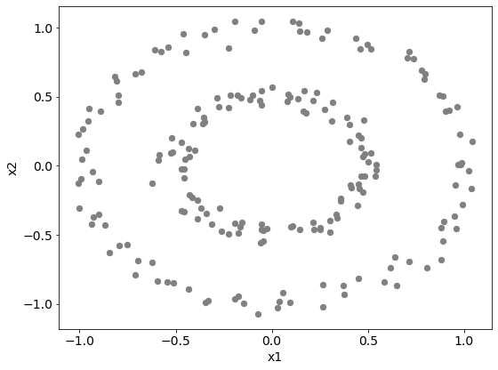

```python
from sklearn.datasets import make_blobs, make_circles
# Create some samples
n_samples = 200
random_state = 170
X, y = make_circles(n_samples=n_samples, factor=0.5, noise=0.05, random_state=random_state)

# X.shape

# Visualize the created dataset
plt.figure(figsize=(8, 6))
plt.rcParams.update({"font.size": 14})
plt.scatter(X[:, 0], X[:, 1], s=40, c='gray', cmap="tab10")
plt.xlabel("x1")
plt.ylabel("x2")
plt.tight_layout()
plt.show()
```

## $k$-means clustering

Let's use $k$-means clustering to cluster the dataset into two clusters.

```
The coordinates of the centroid is
 [[-0.12831176  0.47432578]
 [ 0.1337221  -0.45176973]]
Sum of squared distances of samples to their closest cluster center is 79.86979921355751
```

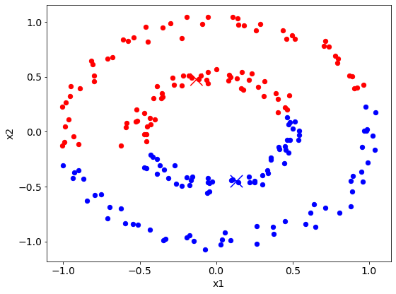

```python
from sklearn.cluster import KMeans

colors = ["#FFC000", "#9DC3E6", "#C27CE8"]

# K-means
k_means = KMeans(n_clusters=2, init="random")
y_pred = k_means.fit_predict(X)

cluster_1 = X[y_pred == 0, :]
cluster_2 = X[y_pred == 1, :]

print(f'The coordinates of the centroid is\n {k_means.cluster_centers_}')
print(f'Sum of squared distances of samples to their closest cluster center is {k_means.inertia_}')

# Visualize the clustering result
plt.figure(figsize=(8, 6))
plt.rcParams.update({"font.size": 14})
plt.scatter(cluster_1[:, 0], cluster_1[:, 1], s=40, c='r')
plt.scatter(cluster_2[:, 0], cluster_2[:, 1], s=40, c='b')
plt.scatter(k_means.cluster_centers_[:, 0], k_means.cluster_centers_[:, 1], s=300, c=['r','b'], marker='x')

plt.xlabel("x1")
plt.ylabel("x2")
plt.tight_layout()
plt.show()
```

We can see that the identified clusters are somewhat based on a linear partition.

## Spectral clustering

Let's see how spectral clustering clusters the data.

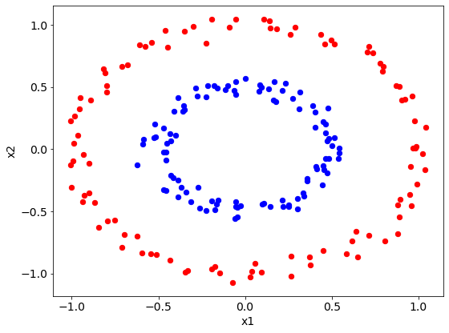

```python
from sklearn.cluster import SpectralClustering

# Spectral clustering
spectral_clustering = SpectralClustering(n_clusters=2, affinity="nearest_neighbors")
y_pred = spectral_clustering.fit_predict(X)

cluster_1 = X[y_pred == 0, :]
cluster_2 = X[y_pred == 1, :]

# Visualize the clustering result
plt.figure(figsize=(8, 6))
plt.rcParams.update({"font.size": 14})
plt.scatter(cluster_1[:, 0], cluster_1[:, 1], s=40, c='r')
plt.scatter(cluster_2[:, 0], cluster_2[:, 1], s=40, c='b')
plt.xlabel("x1")
plt.ylabel("x2")
plt.tight_layout()
plt.savefig("09.svg")
plt.show()
```

Spectral clustering clustered the data into two clusters where each cluster is in a circular form.

Thus, it is evident that spectral clustering is better in case of complex distribution of data.

## Understanding Spectral Clustering

The spectral clustering method from Sklearn has an attribute `affinity_matrix_`.

The values in the affinity matrix reflects the similarity between two points. [Source](https://www.mygreatlearning.com/blog/introduction-to-spectral-clustering/) $$a_{ij} = \text{ simialrity between two points } i \text{ and } j$$

Let's see how the points are connected:

```python
import pandas as pd
import networkx as nx
affinity_mat = spectral_clustering.affinity_matrix_.toarray()
np.fill_diagonal(affinity_mat, 0)
adj_mat = pd.DataFrame(affinity_mat)
G = nx.from_pandas_adjacency(adj_mat)
```

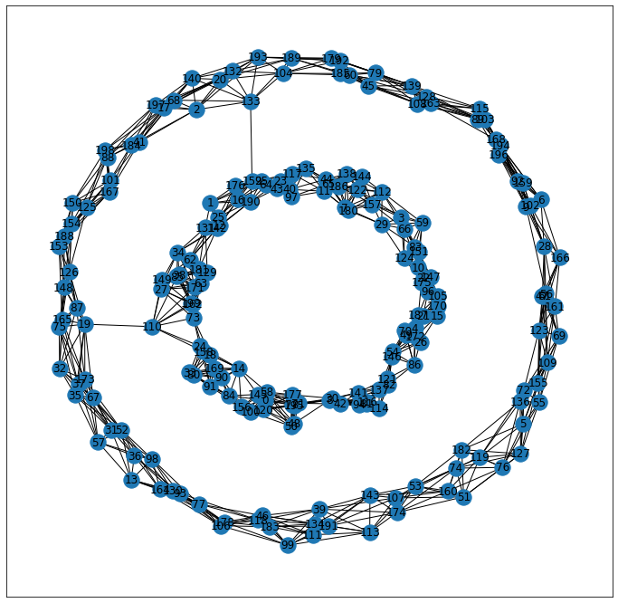

```python
plt.figure(figsize=(12,12))
nx.draw_networkx(G, pos=dict(enumerate(X)))
```

The points lying within a cluster are similar. The points which are similar are connected in the above network. Thus, there are two clusters.

The circles by themselves (i.e. points within each circle) are strongly conncted. The two circles are weakly conncted. It reflects that there are two clusters.